# ProTeomiX (PTX) Quality Control (QC) Report

### 1.4.33 EVD: UpSet distinct

↓ Show Help

The metric shows an upSet plot based on the number of modified peptide sequences per Raw file, intersected or merged with other Raw files (see below for details).

If the number of Raw files is >=6, only the `distinct` plot is generated (the other two are skipped for performance reasons). [See here for an example plot showing how the set size is computed](https://raw.githubusercontent.com/cbielow/PTXQC/master/inst/reportTemplate/modes_UpSet.png) .

Definition: An `active set` is the set of black dots in a column of the plot – as opposed to the grey dots (you will understand when you see it).

**distinct:** shows the number of sequences that are present in ALL active sets. For three Raw files and active sets A and B, this would mean all sequences which occur in A and B (intersect), but not in C (setdiff).  
**intersection:** shows the number of sequences that occurs in all active sets (intersection).  
**union:** shows the number of sequences that occurs in total. For two files that are all sequences that occurs either in A or in B (union).

Heatmap score [EVD: UpSet]: The proportion of sequences that the file has in common with all other files.

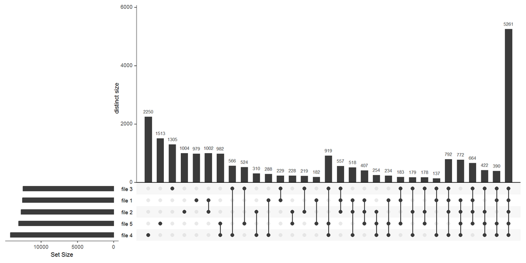

### 1.4.34 EVD: UpSet intersect

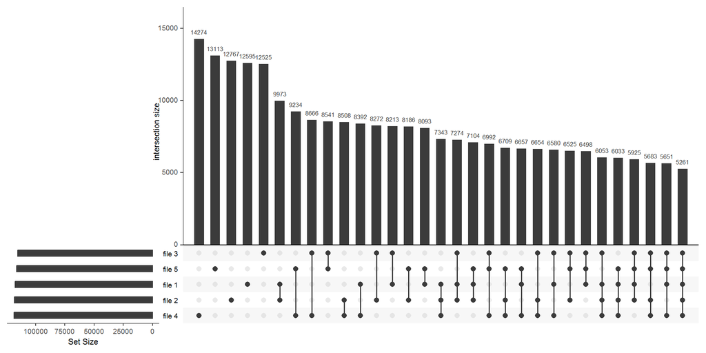

### 1.4.35 EVD: UpSet union

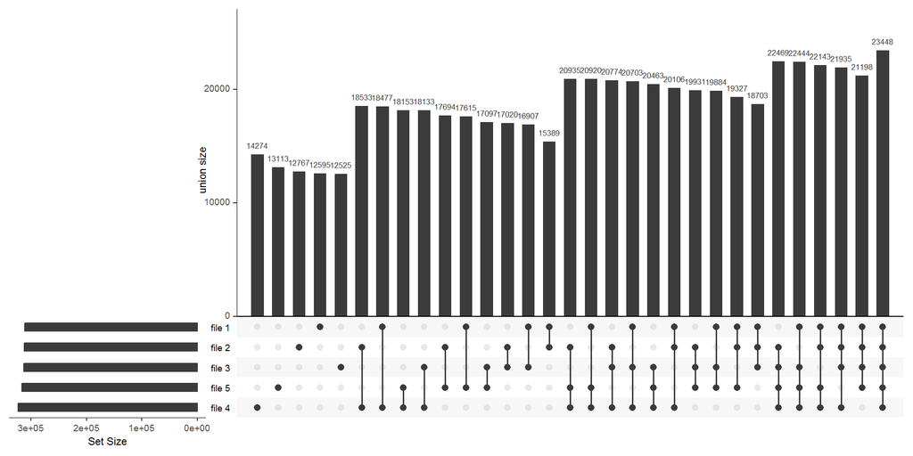

back to top